# Investigate the exponential distribution in R and compare it with the Central Limit Theorem

Sharvari Pawar

## Overview

In this project we will investigate the exponential distribution in R and compare it with the Central Limit Theorem. The exponential distribution can be simulated in R with rexp(n, lambda) where lambda is the rate parameter. The mean of exponential distribution is 1/lambda and the standard deviation is also 1/lambda.

For the project, the following instructions were provided:

Set lambda = 0.2 for all of the simulations. Investigate the distribution of averages of 40 exponentials. Do a thousand simulations.

## Simulations

The below code setups the paramters as outline in the course project instructions. This includes the rate (lambda), number of exponentials and the number of simulations we wish to run.

We then create a numeric vector which contains the result of the simulations. In this case, our simulations are getting the mean.

Finally, we plot a histogram.

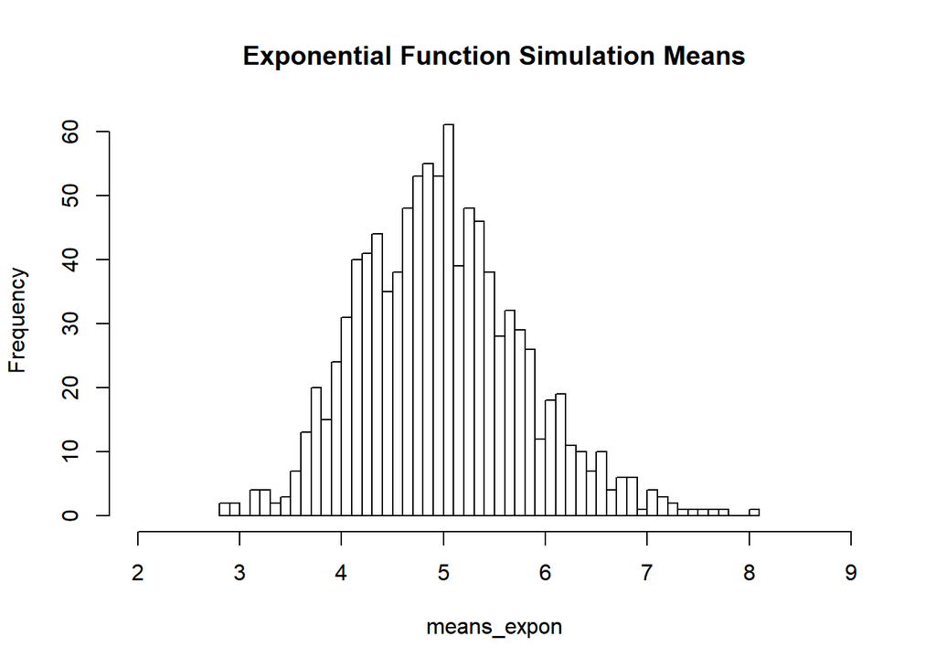

```r
# set seed for reproducibility
set.seed(2016)

# Set sampling values as described in the project instructions
lambda <- 0.2   # lambda

n <- 40         # number of exponentials

sims <- 1000    # number of simulations

#Run simulations
sim_expon <- replicate(sims, rexp(n, lambda))

#Calc the means of the exponential simulations
means_expon <- apply(sim_expon, 2, mean)

#Histogram of the means

hist(means_expon, breaks=40, xlim = c(2,9), main="Exponential Function Simulation Means")
```

## Question 1 - Sample Mean vs Theoretical Mean

The mean of the exponential distribution is 1/lambda. In this case, lambda is 0.2. Therefore, the theoretical mean should result as 5.Let’s see if that’s true.

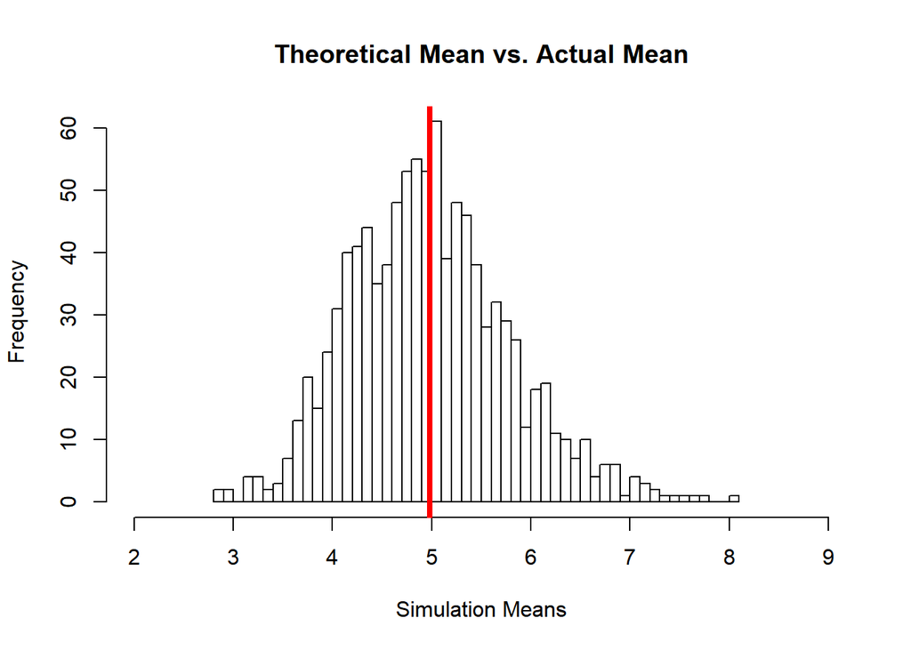

```r
# plot histogram of the sample means
hist(means_expon, main="Theoretical Mean vs. Actual Mean", xlim = c(2,9),breaks=40, xlab = "Simulation Means")

# plot a vertical red line at the mean of the sample means
abline(v=mean(means_expon), lwd="4", col="red")
```

```r
# determine the mean of our sample means
mean(means_expon)
```

```
## [1] 4.979186
```

The code above shows us that our sample mean is 4.979 which is pretty close to our theoretical mean of 5.

## Question 2 - Sample Variance vs Theoretical Variance

```r
# theoretical standard deviation vs. simulation standard deviation
print(paste("Theoretical standard deviation: ",round( (1/lambda)/sqrt(n) ,4)))
```

```
## [1] "Theoretical standard deviation:  0.7906"
```

```r
print(paste("Practical standard deviation: ", round(sd(means_expon) ,4)))
```

```
## [1] "Practical standard deviation:  0.7991"
```

```r
print(paste("Theoretical variance: ", round( ((1/lambda)/sqrt(n))^2 ,4)))
```

```
## [1] "Theoretical variance:  0.625"
```

```r
print(paste("Practical variance: ", round(sd(means_expon)^2 ,4)))
```

```
## [1] "Practical variance:  0.6385"
```

The formulas above show us that the variances are very close.

## Question 3 - Distribution

Finally, we’ll investigate whether the exponential distribution is approximately normal. Due to the Central Limit Theorem, the means of the sample simulations should follow a normal distribution.

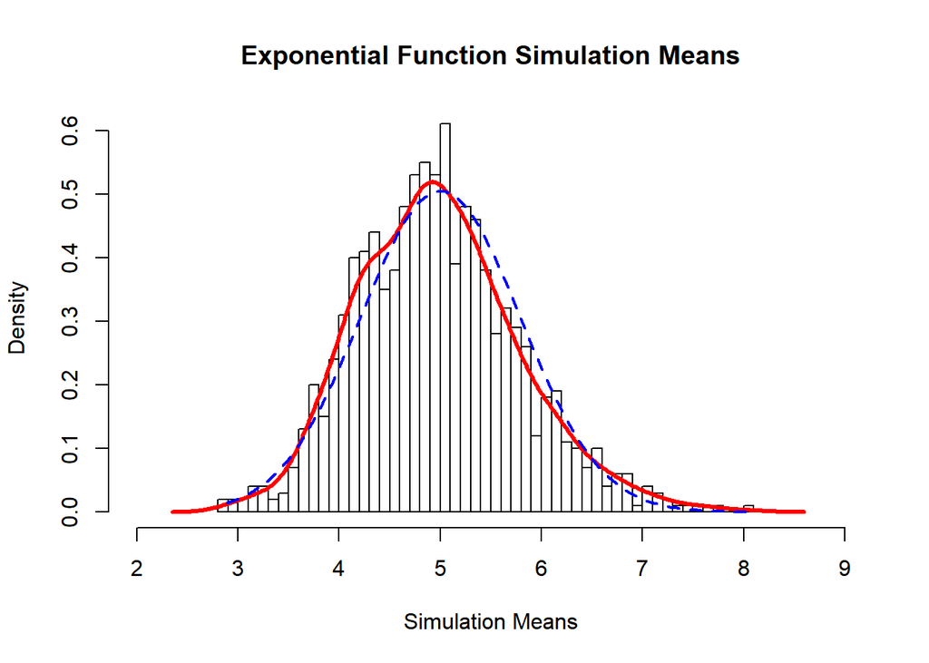

```r
#General Plot with ditribution curve drawn
hist(means_expon, prob=TRUE, main="Exponential Function Simulation Means", breaks=40, xlim=c(2,9), xlab = "Simulation Means")
lines(density(means_expon), lwd=3, col="red")

# Normal distribution line creation
x <- seq(min(means_expon), max(means_expon), length=2*n)
y <- dnorm(x, mean=1/lambda, sd=sqrt(((1/lambda)/sqrt(n))^2))
lines(x, y, pch=22, col="blue", lwd=2, lty = 2)
```